# Focos de Queimadas por Bioma no Brasil entre o ano 1999 e 2021

Luciano Santana

2023-02-28

## Objetivos

O aumento do número de focos de queimadas tem sido constantemente noticiados no Brasil. Levando em consideração essa situação, o estudo do número de focos de queimadas no Brasil se torna um assunto relevante para entendimento. Neste trabalho tivemos como objetivo, analisar e propor um modelo que nos ajude a compreender o número de focos de queimadas no Brasil, no contexto dos biomas nacionais.

## Metodologia

Para analisar a série temporal de queimadas no brasil foram feitos dois modelos, um utilizando o SARIMA e o outro utilizando ETS, com a desagregação hierárquica para os biomas brasileiros. E para definir qual modelo obteve o melhor ajuste, foi feita a comparação usando algumas métricas de avaliação

- RMSE = $\sqrt{\frac{1}{n}\sum^n_{i=1}(x_i-\hat{x})}$
- MAPE = $\frac{1}{n}\sum^n_{i=1}\frac{|x_i-\hat{x}|}{x_i}\cdot 100\%$
- MAE = $\frac{1}{n}\sum^n_{i=1}|x_i-\hat{x}|$

## Análise de dados

```r
queimadas_biomas <- read_excel('queimadas_biomas.xlsx')
dados <- queimadas_biomas %>% filter(date>'1998-12-01' & date<'2021-12-31')
head(dados)
```

```
## # A tibble: 6 x 6
##   ...1  date                  ano mes       number bioma
##   <chr> <dttm>              <dbl> <chr>      <dbl> <chr>
## 1 13    1999-01-01 00:00:00  1999 Janeiro      160 amazonia
## 2 14    1999-02-01 00:00:00  1999 Fevereiro    358 amazonia
## 3 15    1999-03-01 00:00:00  1999 Março        130 amazonia
## 4 16    1999-04-01 00:00:00  1999 Abril         70 amazonia
## 5 17    1999-05-01 00:00:00  1999 Maio         449 amazonia
## 6 18    1999-06-01 00:00:00  1999 Junho       1439 amazonia
```

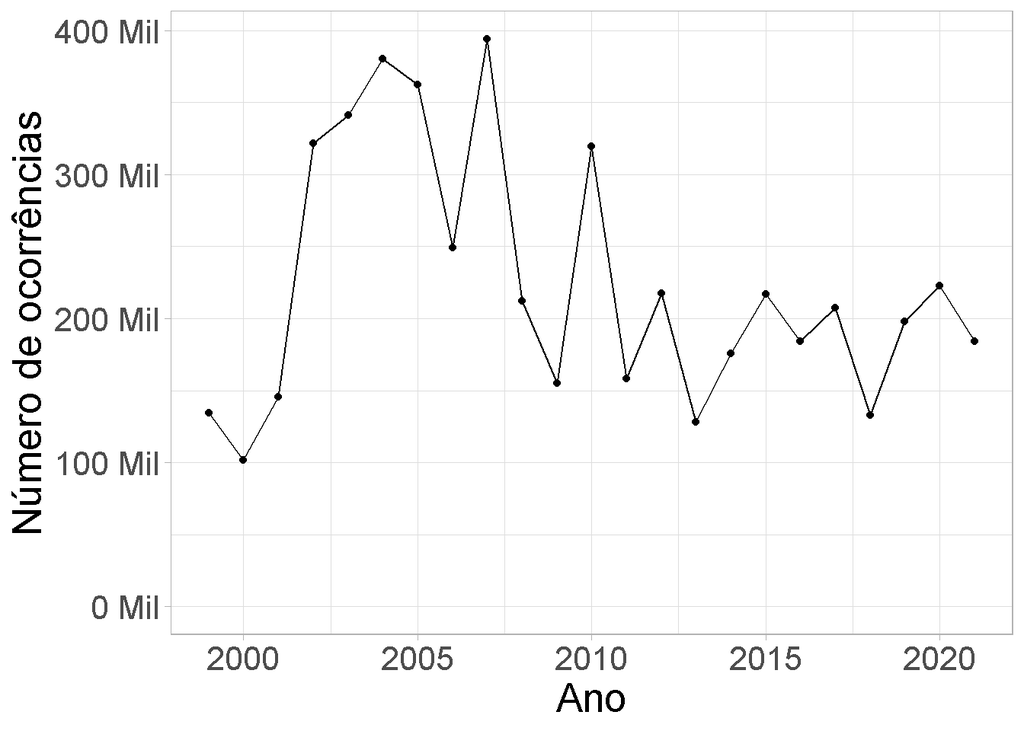

```r
bioma_numb_year <- dados %>% group_by(ano) %>% summarise(ocor = sum(number))
ggplot(bioma_numb_year,aes(x = ano,y = ocor))+
  geom_line()+
  geom_point()+
  labs(x = 'Ano',y = 'Número de ocorrências')+
  expand_limits( y = c(0, NA)) +
  scale_y_continuous(labels = scales::unit_format(unit = "Mil",scale = 10e-4))+
  theme_light()+
  theme(axis.title.x = element_text(size = 20),
        axis.text.x = element_text(size = 16),
        axis.title.y = element_text(size = 20),
        axis.text.y = element_text(siz = 16))
```

Na figura acima é possível observar o ano 2000 sendo a menor marca com 101514 focos de queimadas registradas.No período analisado tivemos uma média anual de 223 mil registros, com o coeficiente de variação anual sendo 39.08%, nos apresentando uma alta variação anual no período estudado. Tivemos apenas 3 anos com registros acima de 350 mil focos de queimadas registrados, o ano 2004 com 380444, o ano 2005 com 362563 e a máxima do período analisado no 2007 com 393914 focos de queimadas.

Na figura abaixo temos um mapa dos biomas do Brasil, em que podemos observar a distribuição dos biomas ao longo do território brasileiro.

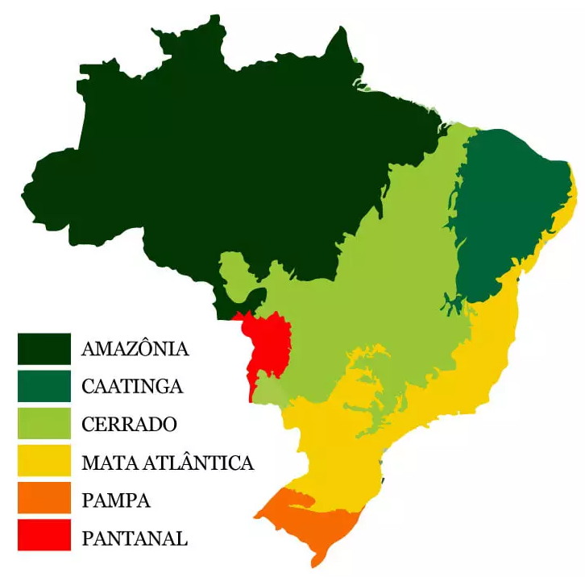

Mapa dos biomas do Brasil

Na Figura acima estão presentes 6 biomas que são definidos pelo IBGE de acordo com suas características climáticas, físicas e entre outras. Na Figura podemos observar que a Amazônia é o bioma que cobre maior parte do território brasileiro com cerca de 49.3%, este bioma se destaca pela sua variedade na flora e fauna, além de possuir o maior ecossistema do mundo, a Floresta Amazônica.

Podemos observar a média e total de focos de queimadas registradas durante 1999 a 2021 por bioma na tabela abaixo.

```r
group_biom <- dados %>% group_by(bioma) %>% summarise(media = mean(number),total = sum(number))
group_biom %>% arrange(desc(media))
```

```
## # A tibble: 6 x 3
##   bioma           media   total
##   <chr>           <dbl>   <dbl>
## 1 amazonia       9170.  2530926
## 2 cerrado        5758.  1589139
## 3 mata_atlantica 1553.   428593
## 4 caatinga       1481.   408676
## 5 pantanal        581.   160282
## 6 pampa            88.4   24406
```

O bioma Amazônia apresentou a maior média registro de focos de queimadas, seguido do Cerrado, e contraponto temos Pantanal e Pampa com menores médias de registro. É possível observar o número total acompanhando as médias históricas da série, com a Amazônia sendo o bioma com maior registro acumulados na série histórica analisada.

Com interesse de entender o comportamento do número de ocorrências de focos de queimadas ao longo dos meses, temos na figura abaixo a distribuição dos registro de focos de queimadas para os biomas brasileiros ao longo dos meses.

```r
biomas_month <- dados %>% group_by(bioma,mes) %>% summarise(soma = sum(number),.groups = "drop")

biomas_month$mes <- sapply(biomas_month$mes,trans_data)
biomas_month
```

```
## # A tibble: 72 x 3
##    bioma    mes          soma
##    <chr>    <chr>       <dbl>
##  1 amazonia 2021-04-01  15334
##  2 amazonia 2021-08-01 611105
##  3 amazonia 2021-12-01 151413
##  4 amazonia 2021-02-01  18857
##  5 amazonia 2021-01-01  35899
##  6 amazonia 2021-07-01 145924
##  7 amazonia 2021-06-01  62941
##  8 amazonia 2021-05-01  23326
##  9 amazonia 2021-03-01  24331
## 10 amazonia 2021-11-01 301803
## # ... with 62 more rows
```

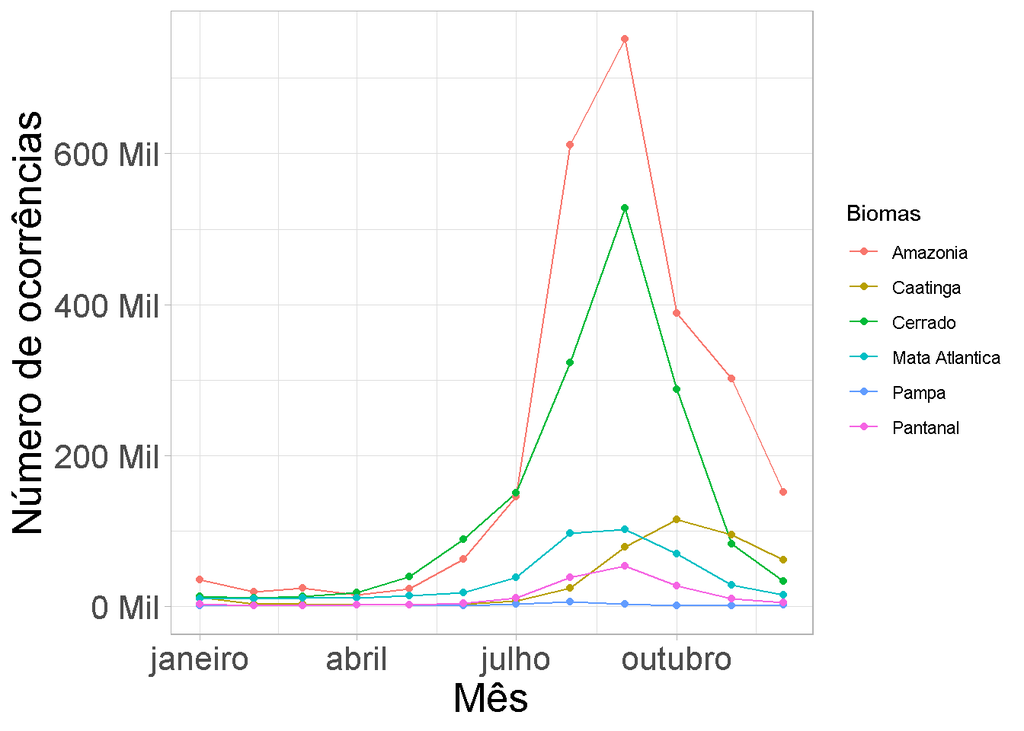

```r
ggplot(biomas_month,aes(x = as.Date(mes),y = soma,color = str_to_title(str_replace(bioma,'_',' '))))+
  scale_x_date(labels = date_format('%B'))+
  geom_line()+
  geom_point()+
  #  geom_smooth(se = F)+
  labs(x = 'Mês',y = 'Número de ocorrências')+
  theme_light()+
  expand_limits( y = c(0, NA)) +
  scale_y_continuous(labels = scales::unit_format(unit = "Mil",scale = 10e-4))+
  scale_color_discrete(name = 'Biomas')+
  theme(axis.title.x = element_text(size = 20),
        axis.text.x = element_text(size = 16),
        axis.title.y = element_text(size = 20),
        axis.text.y = element_text(siz = 16))
```

É possível observar na figura acima um comportamento similar entres os biomas ao longo dos meses, o primeiro semestre do ano sendo um período com menores registros de focos de queimadas, sendo acentuando a partir de julho. Os biomas Amazônia e Cerrado tem sua média máxima histórica em setembro, diferente da Caatinga que apresenta essa máxima no mês de outubro.

Vamos agora ajustar modelos para a série histórica de foco de queimadas em todo o Brasil.

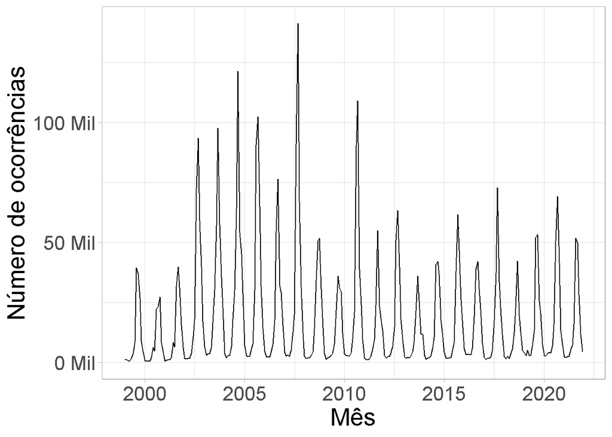

```r
x <- dados %>% group_by(date) %>% summarise(tot = sum(number))
ggplot(x,aes(x = date,y = tot))+
  geom_line()+
  labs(x = 'Mês',y = 'Número de ocorrências')+
  theme_light()+
  expand_limits( y = c(0, NA)) +
  scale_y_continuous(labels = scales::unit_format(unit = "Mil",scale = 10e-4))+
  scale_color_discrete(name = 'Biomas')+
  theme(axis.title.x = element_text(size = 20),
        axis.text.x = element_text(size = 16),
        axis.title.y = element_text(size = 20),
        axis.text.y = element_text(siz = 16))
```

Podemos perceber na figura acima que há a presença de sazonalidade, onde temos seus picos nos meses de Agosto e Setembro, vemos também que não há uma tendência clara. Nota-se que entre os anos de 2005 e 2010 registrou-se níveis mais elevados do número de queimadas no país, com alguns meses registrando mais de 100 mil focos de incêndio. Já nos últimos anos de observação nota-se uma estabilização desta série.

```r
queimadas_biomas <- queimadas_biomas %>%
  dplyr::mutate(date = tsibble::yearmonth(.data$date)) %>%
  tsibble::as_tsibble(key = "bioma", index = "date")
```

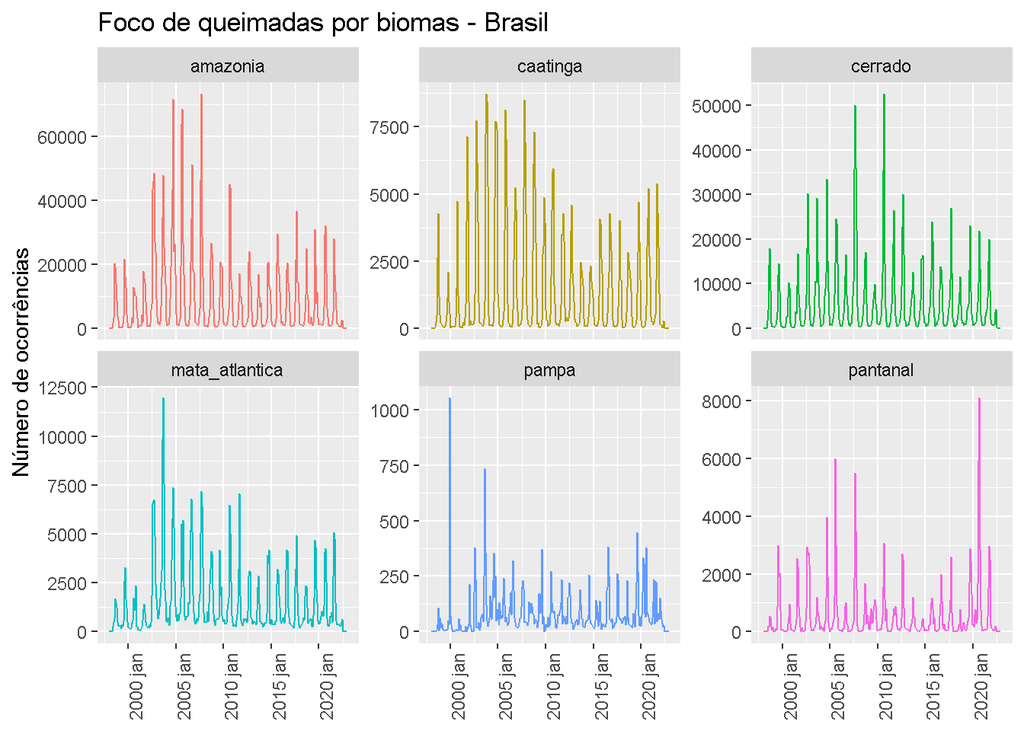

```r
queimadas_biomas %>%
  fabletools::autoplot(number) +
  ggplot2::facet_wrap(
    ~bioma,
    scales = "free_y"
  ) +
  ggplot2::labs(
    title = "Foco de queimadas por biomas - Brasil",
    x = NULL,
    y = "Número de ocorrências",
  ) +
  ggplot2::theme(legend.position = "none",
                 axis.text.x = element_text(angle = 90))
```

## Ajuste de modelo e previsão

No ajuste dos modelos foram utilizados o SARIMA e ETS. Para ajustar os modelos dividimos nossa base em treinamento, nosso treinamento consistia nos dados até o ano de 2020, e para validação do modelo testaríamos nossos modelos prevendo o ano 2021. Foi utilizado o pacote “fable” do software R, que nos fornece uma coleção de modelos de séries temporais univariadas e multivariadas.

Utilizando o método de séries hierárquicas foram ajustados modelos para os 6 biomas brasileiros, além do modelo intitulado como “agregado”, referente ao modelo para ajuste do Brasil inteiro.

```r
prod_biomas <- queimadas_biomas %>%
  dplyr::filter(!bioma == "Total") %>%
  fabletools::aggregate_key(bioma, number = sum(number, na.rm = TRUE))
prod_biomas
```

```
## # A tsibble: 2,100 x 3 [1M]
## # Key:       bioma [7]
##        date bioma        number
##       <mth> <chr*>        <dbl>
##  1 1998 jan <aggregated>      0
##  2 1998 fev <aggregated>      0
##  3 1998 mar <aggregated>      0
##  4 1998 abr <aggregated>      0
##  5 1998 mai <aggregated>      0
##  6 1998 jun <aggregated>   3551
##  7 1998 jul <aggregated>   8067
##  8 1998 ago <aggregated>  35551
##  9 1998 set <aggregated>  41950
## 10 1998 out <aggregated>  23468
## # ... with 2,090 more rows
```

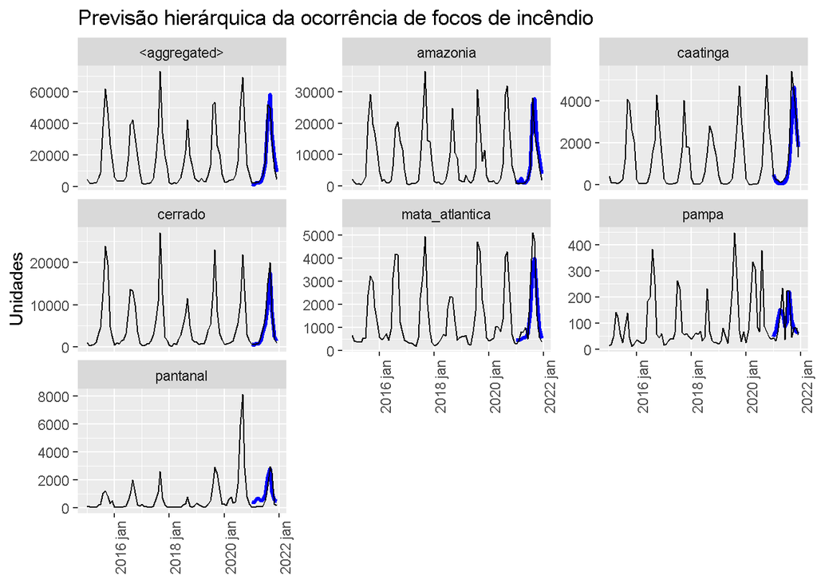

```r
# ARIMA

arima.fit <- prod_biomas %>%
  dplyr::filter(lubridate::year(.data$date) <= 2020) %>%
  fabletools::model(baseline = fable::ARIMA(number))


arima.fcst <- fabletools::forecast(arima.fit, h = 12)

arima.fcst %>%
  fabletools::autoplot(
    dplyr::filter(
      prod_biomas,
      dplyr::between(
        lubridate::year(.data$date),
        2015,
        2021
      )
    ),
    level = NULL,
    size = 1.1
  ) +
  ggplot2::facet_wrap(
    ~bioma,
    scales = "free_y"
  ) +
  ggplot2::labs(
    title = "Previsão hierárquica da ocorrência de focos de incêndio",
    y = "Unidades",
    x = NULL
  )+
  ggplot2::theme(legend.position = "none",
                 axis.text.x = element_text(angle = 90))
```

Na figura acima, temos a previsão hierárquica da ocorrência de focos de incêndio no Brasil para o ano de 2021 para o modelo SARIMA. Analisando pelo gráfico, podemos observar a previsão tendo um comportamento semelhante ao valor real da série tanto para o agregado, quanto para os biomas.

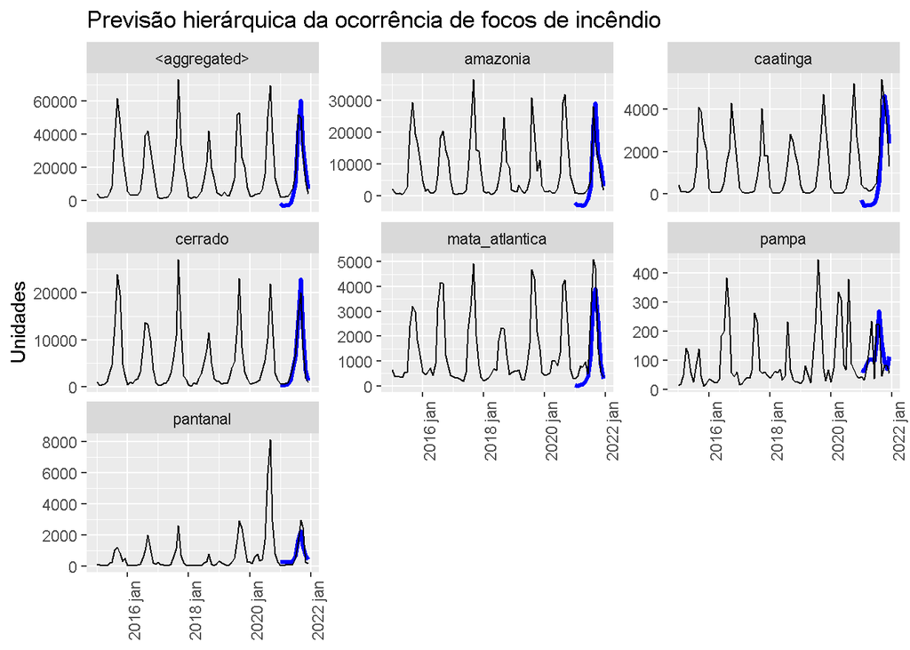

```r
# ETS

ets.fit <- prod_biomas %>%
  dplyr::filter(lubridate::year(.data$date) <= 2020) %>%
  fabletools::model(baseline = fable::ETS(number))


ets.fcst <- fabletools::forecast(ets.fit, h = 12)

ets.fcst %>%
  fabletools::autoplot(
    dplyr::filter(
      prod_biomas,
      dplyr::between(
        lubridate::year(.data$date),
        2015,
        2021
      )
    ),
    level = NULL,
    size = 1.1
  ) +
  ggplot2::facet_wrap(
    ~bioma,
    scales = "free_y"
  ) +
  ggplot2::labs(
    title = "Previsão hierárquica da ocorrência de focos de incêndio",
    y = "Unidades",
    x = NULL
  )+
  ggplot2::theme(legend.position = "none",
                 axis.text.x = element_text(angle = 90))
```

No modelo ETS, as previsões para 2021 em que podemos observar na figura acima apresentam estimações parecidas ao modelo SARIMA, porém é possível observar algumas diferenças significativas como no biomas Pampa.

```r
arima.accuracia <- arima.fcst %>%
#  dplyr::filter(fabletools::is_aggregated(bioma)) %>%
  fabletools::accuracy(prod_biomas) %>%
  dplyr::arrange(RMSE)

arima_acuracia <- data.frame(arima.accuracia[,-1] %>% arrange(bioma) %>% select(MAE,RMSE,MAPE))
ari_acuracia <- data.frame(t(arima_acuracia))
colnames(ari_acuracia) <- c(unique(queimadas_biomas$bioma),'Brasil')
ari_acuracia
```

```
##        amazonia  caatinga    cerrado mata_atlantica    pampa pantanal
## MAE  2090.30167 448.06734 1031.40253      504.54789 39.99475 507.5760
## RMSE 3536.53457 792.21478 1729.83771      650.91523 54.52885 592.6541
## MAPE   65.79576  40.24776   23.57888       39.53582 53.75943 458.1703
##          Brasil
## MAE  3414.43045
## RMSE 4646.00907
## MAPE   30.80794
```

```r
ets.accuracia <- ets.fcst %>%
#  dplyr::filter(fabletools::is_aggregated(bioma)) %>%
  fabletools::accuracy(prod_biomas) %>%
  dplyr::arrange(RMSE)

etss_acuracia <- data.frame(ets.accuracia[,-1] %>% arrange(bioma) %>% select(MAE,RMSE,MAPE))
ets_acuracia <- data.frame(t(etss_acuracia))
colnames(ets_acuracia) <- c(unique(queimadas_biomas$bioma),'Brasil')
ets_acuracia
```

```
##       amazonia  caatinga   cerrado mata_atlantica    pampa pantanal    Brasil
## MAE  4035.5982  929.0536 1078.3124      707.92907 50.88106 354.6118 5971.1345
## RMSE 4880.2269 1066.3473 1567.2512      860.90290 62.76550 469.3998 6353.0080
## MAPE  227.6675  194.3988   32.7842       60.68895 71.65530 235.9980  102.9115
```

Após o ajuste e comparação dos modelos analisados ao longo do projeto, chegamos a conclusão de que em diferentes biomas, as técnicas de previsão alcançam resultados distintos, deste modo é preferível que para chegar a melhores métricas sejam utilizados modelos específicos dentre o SARIMA e ETS.

Já para a análise do Brasil como um todo, observamos que o modelo SARIMA obteve os melhores resultados na nossa avaliação em comparação ao ETS.